# SNAG: T1 and T2 subfields

## PHC

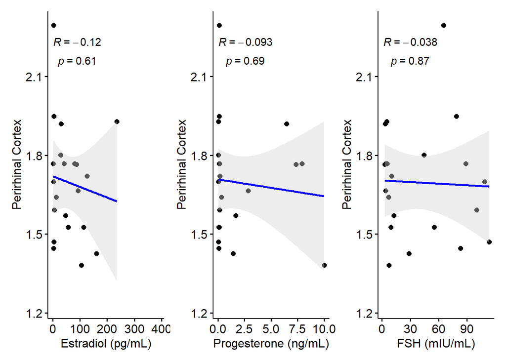

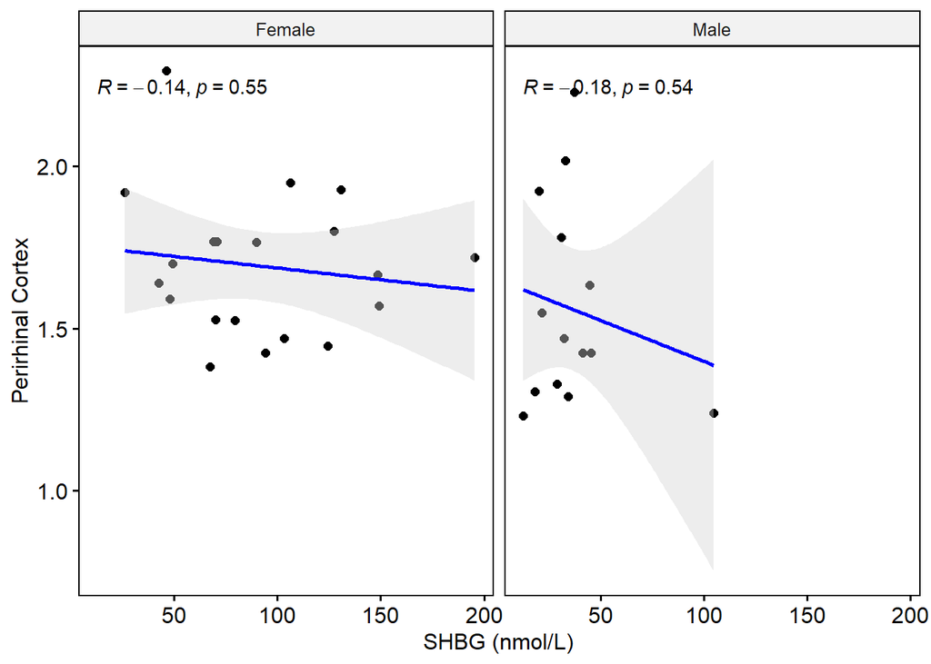

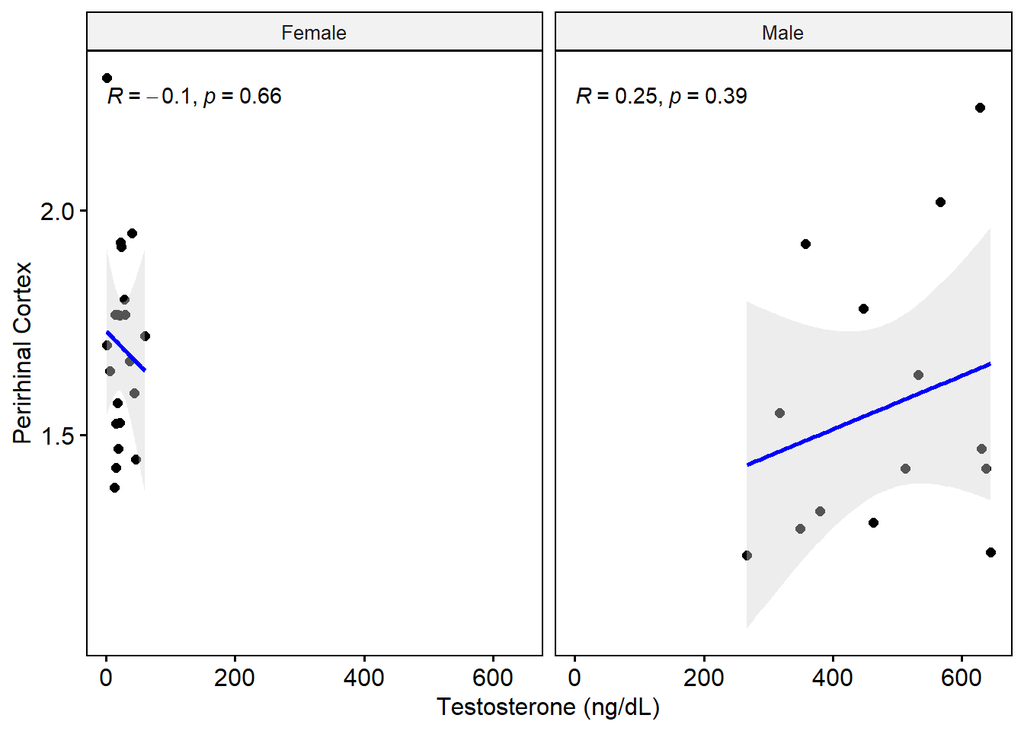

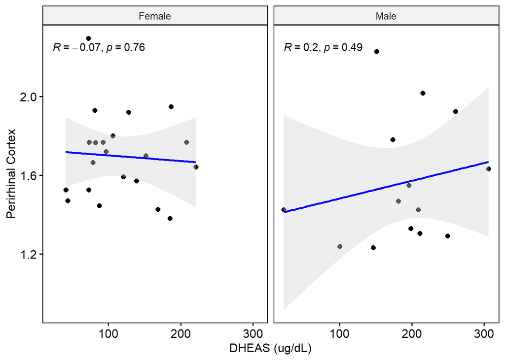

## SUB

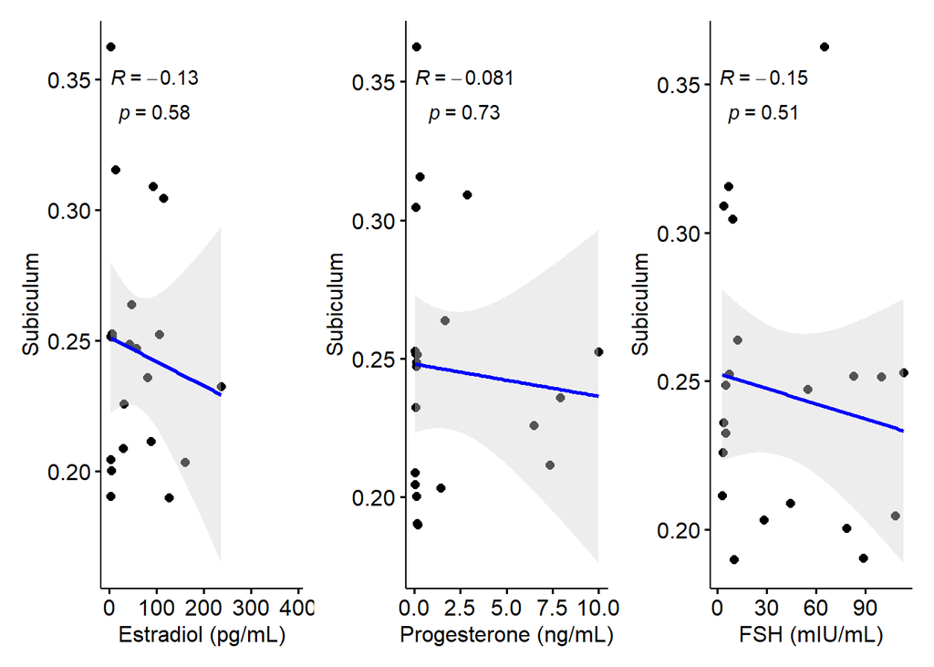

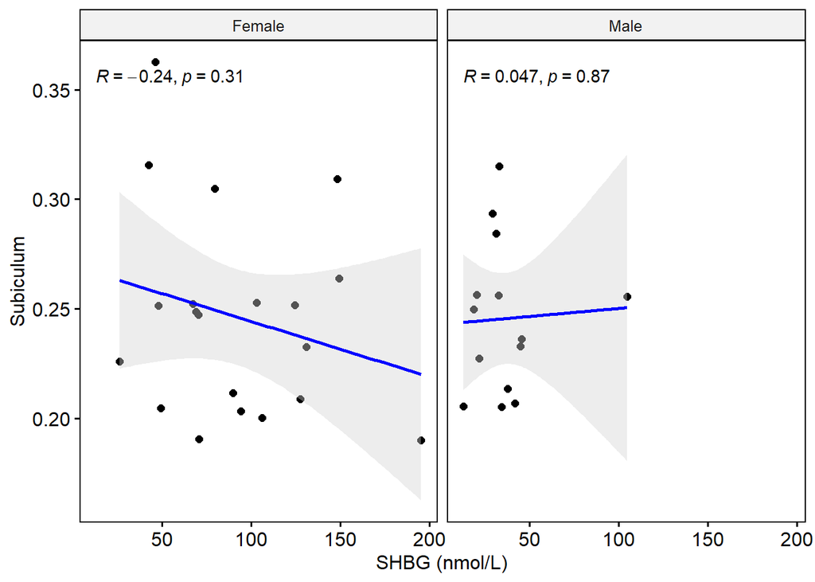

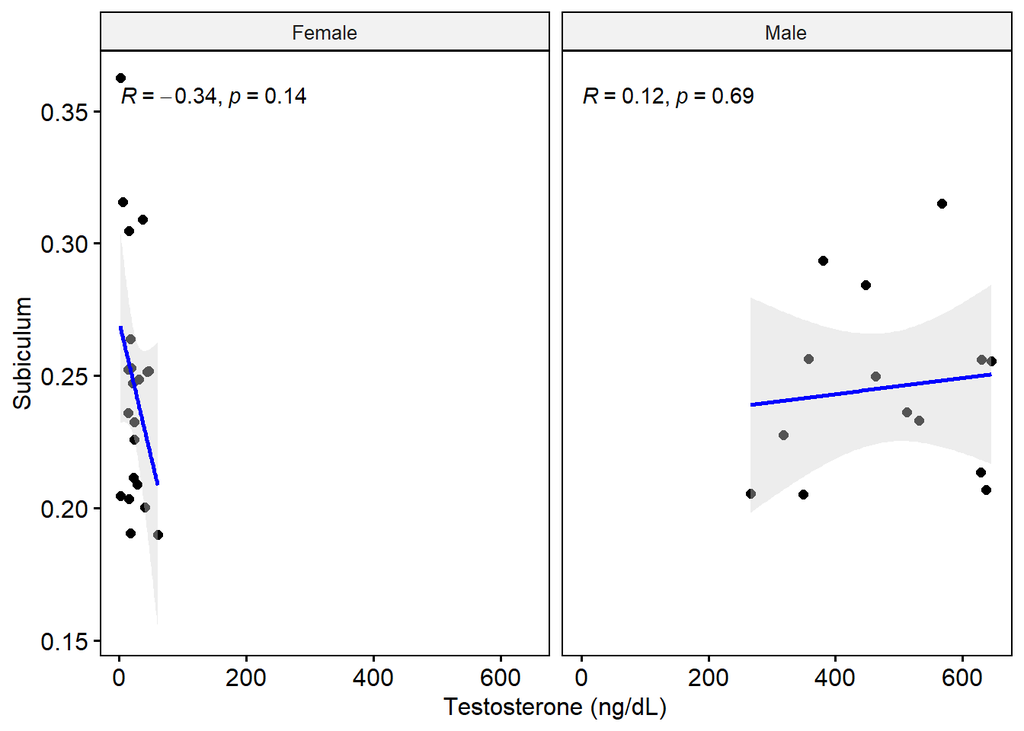

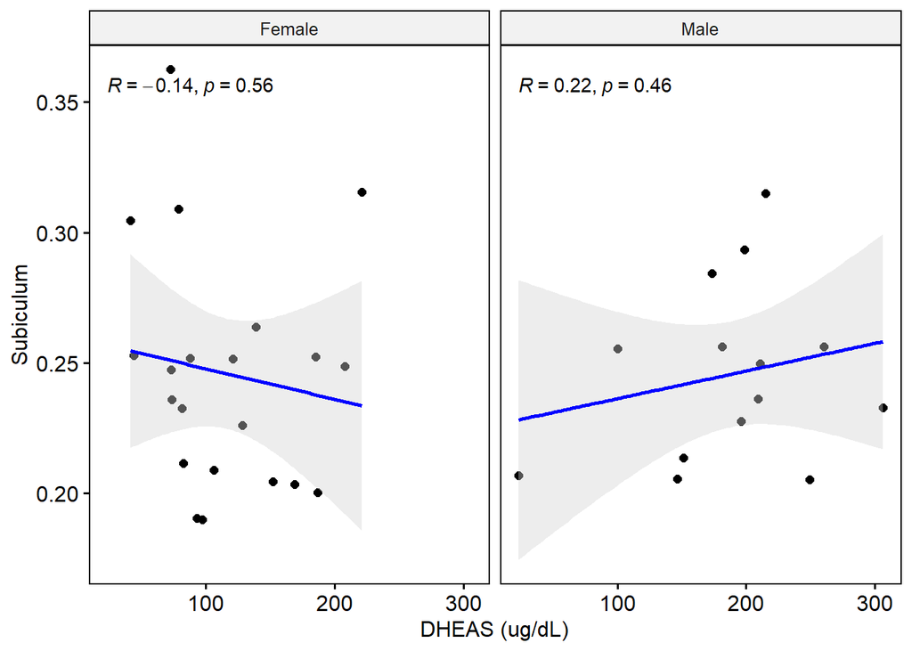

## PHG

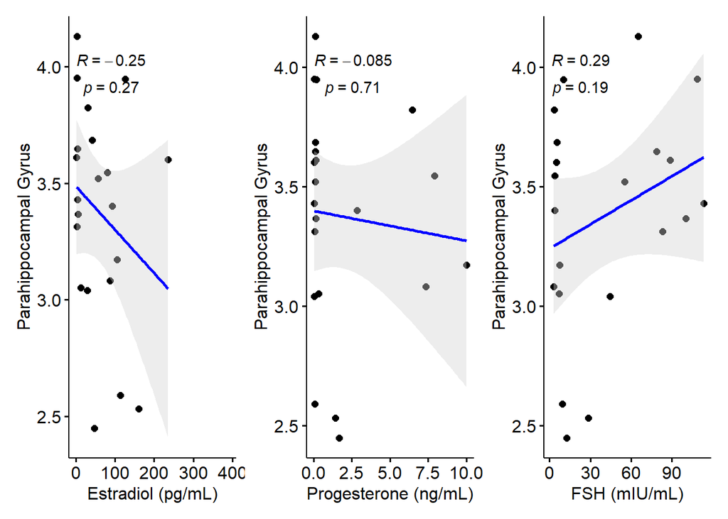

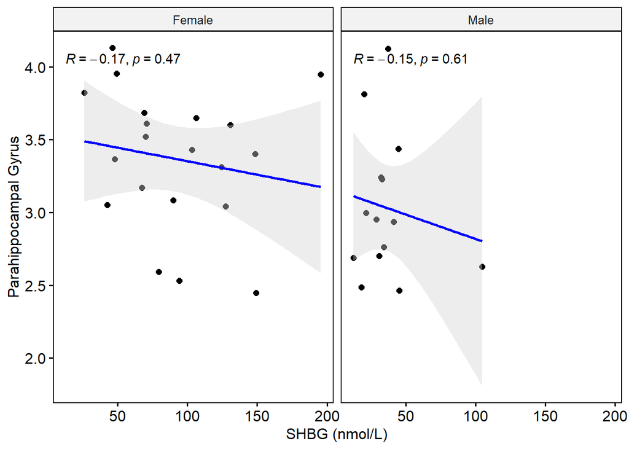

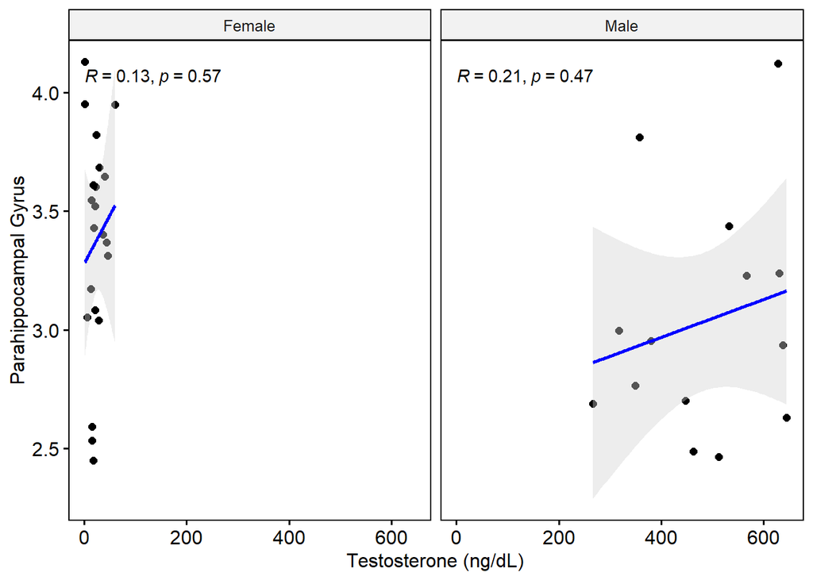

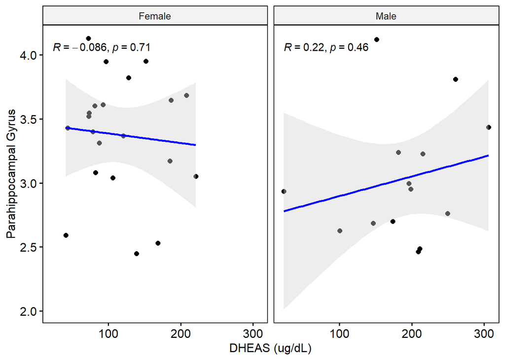

# Summary

Initial findings include:

- For T1 brain data, total hippocampal and MTL volumes are marginally and negatively associated with FSH
- For CA1 and CA2/3, they are marginally and negatively associated with FSH. CA2/3 is also marginally and negatively associated with testosterone for women
- For ERC, it is marginally and positively associated with testosterone in men

Future directions:

- Finish data collection and re-evaluate analysis with larger and complete sample